# Germination Data Analysis Solutions

Author

Aarav, Carson, and Jared

## Learning Objectives

- Learn how to implement tidyverse functions to analyze and interpret real-world ecological germination data.
- Create summary statistics + visualizations to compare germination rates across treatments, species, concentrations, and environmental conditions.
- Practice writing reusable R functions using tidy evaluation techniques such as the embrace operator (`{ }`).
- Use iteration tools from the `purrr` package to efficiently repeat analyses across multiple treatment groups or variables.
- Explore distributions + simulation methods to better understand variability in germination outcomes.
- Practice writing reproducible, well-documented, + readable R code for ecological data analysis.

## Dataset Description

The dataset used in this lab contains germination data collected during a 2025 summer ecology study from Carson investigating the effects of fire retardants on grassland species. Specifically, the study examined how two fire retardants, Phos-Chek and Clore, influenced the germination of Purple Needle Grass (PNG) and Italian Ryegrass (RYE).

For each observation, the number of seeds germinated out of 10 total seeds was recorded weekly over a four-week period. The dataset includes the following variables:

- `week` – week of observation during the experiment
- `species` – plant species being tested
- `substrate` – substrate or soil type used
- `treatment_type` – fire retardant treatment applied
- `concentration` – concentration level of treatment
- `dish_number` – petri dish identification number
- `seeds_germinated_out_of_10` – number of seeds germinated out of 10 total seeds

This dataset contains a large number of observations and multiple treatment combinations, that allows for practice with data visualization, summary statistics, iteration, functions, and simulation techniques.

## Download the Data

Download the dataset for this lab: Germination_Data_Entry_1.xlsx

Save this Excel sheet in your project folder before running the code in this lab.

## Import Libraries

**NoteNote**

If you have not previously installed these packages, run:

```r
install.packages("readxl")
install.packages("tidyverse")
install.packages("janitor")
install.packages("knitr")
install.packages("gt")
```

in the Console once. After the packages are installed, you can load them in future sessions using `library()`.

```r
library(readxl)
library(tidyverse)
library(janitor)
library(knitr)
library(gt)
```

## Read Data

**WarningWarning**

If you change the name of the dataset file, be sure to update the filename used in `read_excel()` below.

```r
germination <- read_excel("Germination_Data_Entry_1.xlsx")
germination <- clean_names(germination)
```

## Preview the Data

**Question 0: Let’s first poke around and get a sense of the dataset. What is the number of observations and variables? Are there any missing values?**

**TipTip**

You can use `glimpse()` and `colSums(is.na())` to answer the question above!

The dataset contains 640 observations and 7 variables related to seed germination experiments. The output from `glimpse()` provides an overview of the variable names, data types, and some values, while the output from `colSums(is.na())` confirms that there are no missing values in the dataset.

```r
glimpse(germination)
```

```
Rows: 640
Columns: 7
$ week                       <dbl> 1, 1, 1, 1, 1, 1, 1, 1, 1, 1, 1, 1, 1, 1, 1…
$ species                    <chr> "RYE", "RYE", "RYE", "RYE", "RYE", "RYE", "…
$ substrate                  <chr> "Soil", "Soil", "Soil", "Soil", "Soil", "So…
$ treatment_type             <chr> "Phos", "Phos", "Phos", "Phos", "Phos", "Ph…
$ concentration              <dbl> 1.000, 1.000, 1.000, 1.000, 0.500, 0.500, 0…
$ dish_number                <dbl> 1, 2, 3, 4, 1, 2, 3, 4, 1, 2, 3, 4, 1, 2, 3…
$ seeds_germinated_out_of_10 <dbl> 0, 0, 0, 0, 0, 0, 0, 0, 0, 1, 0, 1, 4, 0, 0…
```

```r
colSums(is.na(germination))
```

```
                      week                    species
                         0                          0
                 substrate             treatment_type
                         0                          0
             concentration                dish_number
                         0                          0
seeds_germinated_out_of_10
                         0
```

## Questions

**Question 1: Which treatment type had the highest average germination percentage for each species? Create a summary table and display the relationship between treatment type and average germination percentage using a bar plot.**

```r
treatment_summary <- germination |>
  group_by(species, treatment_type) |>
  summarize(
    average_germination_percent =
    mean(seeds_germinated_out_of_10 / 10 * 100),
    .groups = "drop"
  )

treatment_summary |>
  kable()
```

| species | treatment_type | average_germination_percent |
| --- | --- | --- |
| PNG | Clore | 14.0625 |
| PNG | Phos | 12.0000 |
| RYE | Clore | 12.8750 |
| RYE | Phos | 22.4375 |

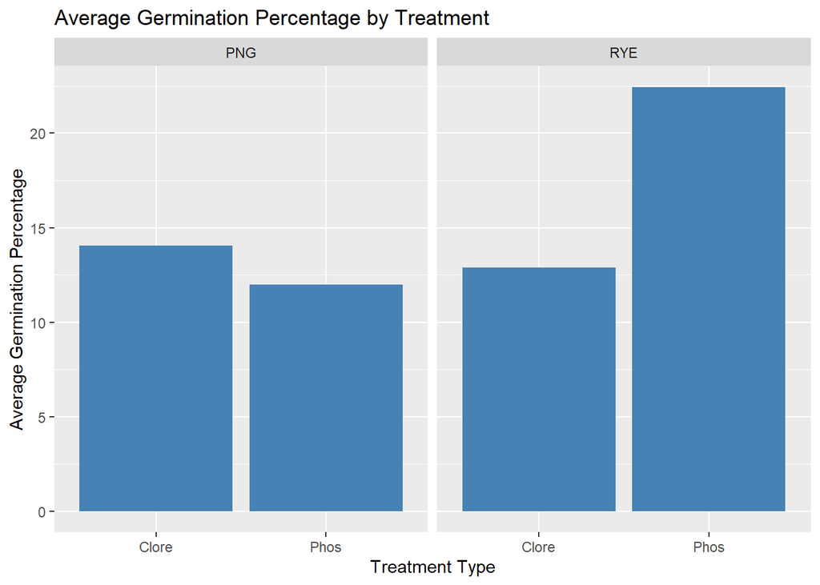

```r
ggplot(treatment_summary,
       aes(x = treatment_type,
           y = average_germination_percent)) +
  geom_col(fill = "steelblue") +
  facet_wrap(~ species) +
  labs(
    title = "Average Germination Percentage by Treatment",
    x = "Treatment Type",
    y = "Average Germination Percentage"
  )
```

For PNG, the Clore treatment had a slightly higher average germination percentage than Phos. In contrast, RYE had a much higher germination percentage under the Phos treatment. The bar plot makes these differences easier to visualize by using the table values and displaying them side by side for each species.

**Question 2: Create a faceted line graph detailing the frequencies for seeds germinated between different concentrations. Lines should be separated by the treatment and it should be faceted by the weeks.**

**Tip**

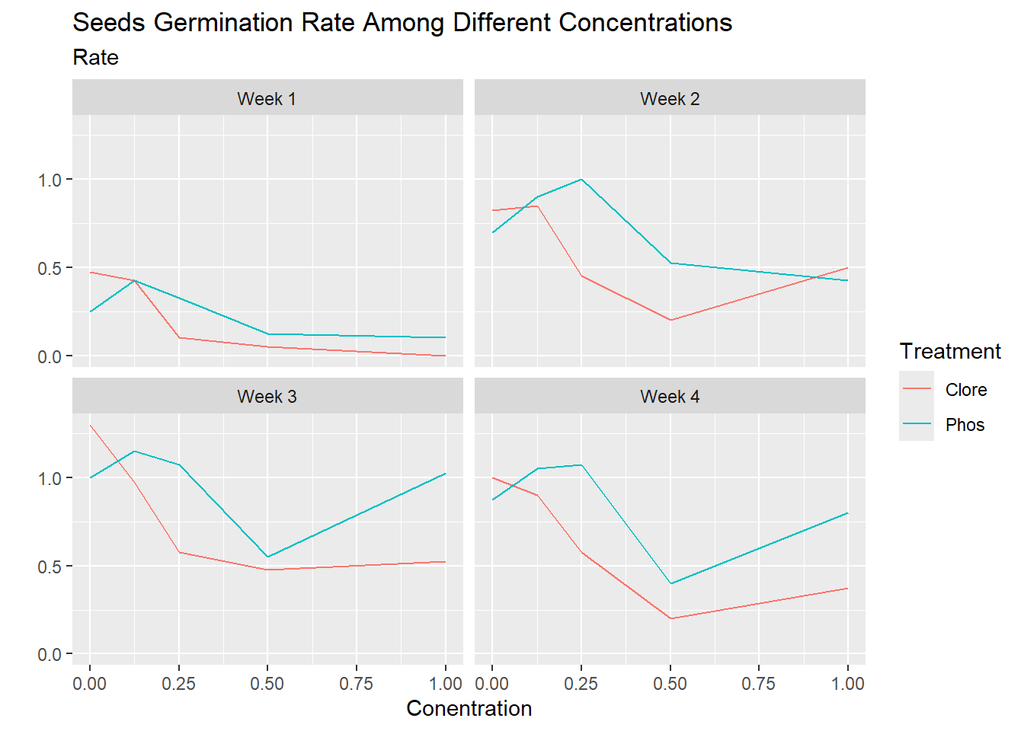

```r
germination |>
  mutate(week=fct_recode(as.character(week),"Week 1"="1",
                         "Week 2"="2",
                         "Week 3"="3",
                         "Week 4"="4")) |>
  group_by(week,treatment_type,concentration) |>
  summarise(freq=sum(seeds_germinated_out_of_10)/40,
            .groups="drop") |>
  ggplot(mapping=aes(x=concentration,
                     y=freq,
                     color=treatment_type))+
  geom_line()+
  facet_wrap(~week)+
  labs(title="Seeds Germination Rate Among Different Concentrations",
       subtitle="Rate",
       x="Conentration",
       y="",
       color="Treatment")
```

**Question 3: Create a table using `gt()` that displays the mean germination for each species and fire retardant from week 4.** **Hint: there should be 3 columns and 4 rows.**

```r
germination |>

  filter(week == 4) |>

  group_by(species, treatment_type) |>

  summarize(
    mean_germination = mean(seeds_germinated_out_of_10, na.rm = TRUE),
    .groups = "drop") |>

  gt() |>
  tab_header(
    title = "Mean Germination at Week 4",
    subtitle = "Grouped by Species and Fire Retardant Treatment") |>

   fmt_number(
    columns = mean_germination,
    decimals = 3) |>

  cols_label(
    species = "Species",
    treatment_type = "Fire Retardant",
    mean_germination = "Mean Germination (out of 10)")
```

Mean Germination at Week 4

Grouped by Species and Fire Retardant Treatment

| Species | Fire Retardant | Mean Germination (out of 10) |
| --- | --- | --- |
| PNG | Clore | 1.500 |
| PNG | Phos | 1.425 |
| RYE | Clore | 1.550 |
| RYE | Phos | 2.775 |

**Question 4: Write a reusable function called `germination_success()` that calculates the percentage of observations where at least half of the seeds germinated. For this question, define a successful observation as one where at least 5 out of 10 seeds germinated. Use your function to calculate germination success percentages by species.**

Your function should:

- use a grouping variable chosen by the user
- use the embrace operator (`{ }`)
- return the success percentage for each group

```r
germination_success <- function(data, var){
  data |>
    group_by({{ var }}) |>
    summarize(
      success_percent =
        round(mean(seeds_germinated_out_of_10 >= 5) * 100, 2)
    )
}
```

```r
germination_success(germination, species) |>
  kable(caption = "Germination Success Percentage by Species")
```

Germination Success Percentage by Species

| species | success_percent |
| --- | --- |
| PNG | 6.25 |
| RYE | 12.81 |

The table shows the percentage of observations where at least 5 out of 10 seeds successfully germinated for each species. These results suggest that RYE generally germinated more successfully than PNG under the treatment conditions included in this dataset.

**Question 5: Create a new variable called `germination_levels`, then create a summary table showing the number of observations in each germination level for each species.**

Classify the observations as:

- Low: 0–3 seeds germinated
- Moderate: 4–7 seeds germinated
- High: 8–10 seeds germinated

```r
germination_levels <- germination |>
  mutate(
    germination_level = factor(
      case_when(
        seeds_germinated_out_of_10 <= 3 ~ "Low",
        seeds_germinated_out_of_10 <= 7 ~ "Moderate",
        seeds_germinated_out_of_10 <= 10 ~ "High"),
      levels = c("Low", "Moderate", "High")
    )
  )
germination_levels |>
  group_by(species, germination_level) |>
  summarize(
    observations = n(),
    .groups = "drop"
  ) |>
  kable(caption = "Observations by Germination Level and Species")
```

Observations by Germination Level and Species

| species | germination_level | observations |
| --- | --- | --- |
| PNG | Low | 282 |
| PNG | Moderate | 37 |
| PNG | High | 1 |
| RYE | Low | 263 |
| RYE | Moderate | 49 |
| RYE | High | 8 |

Most observations for both species were classified in the Low germination category, meaning that 0–3 seeds germinated in the majority of cases. These results also suggest that RYE generally had stronger germination outcomes than PNG under the treatment conditions included in this dataset.

**Question 6: Use `map()` to count how many Low, Moderate, and High germination observations occurred in each week. Which week had the strongest germination performance?**

**NoteNote**

There are multiple ways to solve this problem. While this solution uses `map()` to practice iteration, you can achieve the same result using `group_by()` and `summarize()`. You may try exploring an alternative solution on your own.

```r
week_levels <- map(
  unique(germination_levels$week),
  ~ germination_levels |>
    filter(week == .x) |>
    count(germination_level,
          name = "observations",
          .drop = FALSE) |>
    mutate(week = .x)
)

bind_rows(week_levels) |>
  pivot_wider(
    names_from = germination_level,
    values_from = observations
  ) |>
  kable(caption = "Germination Levels by Week")
```

Germination Levels by Week

| week | Low | Moderate | High |
| --- | --- | --- | --- |
| 1 | 156 | 4 | 0 |
| 2 | 135 | 23 | 2 |
| 3 | 124 | 31 | 5 |
| 4 | 130 | 28 | 2 |

These results suggest that germination outcomes improved over time for some observations, with Week 3 showing the strongest overall germination performance since it had the most High observations with 5.

**Question 7: Gather the mean and standard deviation of the seeds germinated. With these, create a simulation 1000 samples and graph a normal distribution. Then, graph the true distribution of seeds germinated out of 10 based on the original data and graph it within the same normal distribution graph. Compare those two distributions.**

**Tip**

Use `set.seed(3452)`. Use functions `scale_fill_manual` to separate and `after_stat(density)` within the histogram aesthetic.

```r
germination|>
  summarize(avg=mean(seeds_germinated_out_of_10),
            sd=sd(seeds_germinated_out_of_10)) |>
  kable()
```

| avg | sd |
| --- | --- |
| 1.534375 | 1.972917 |

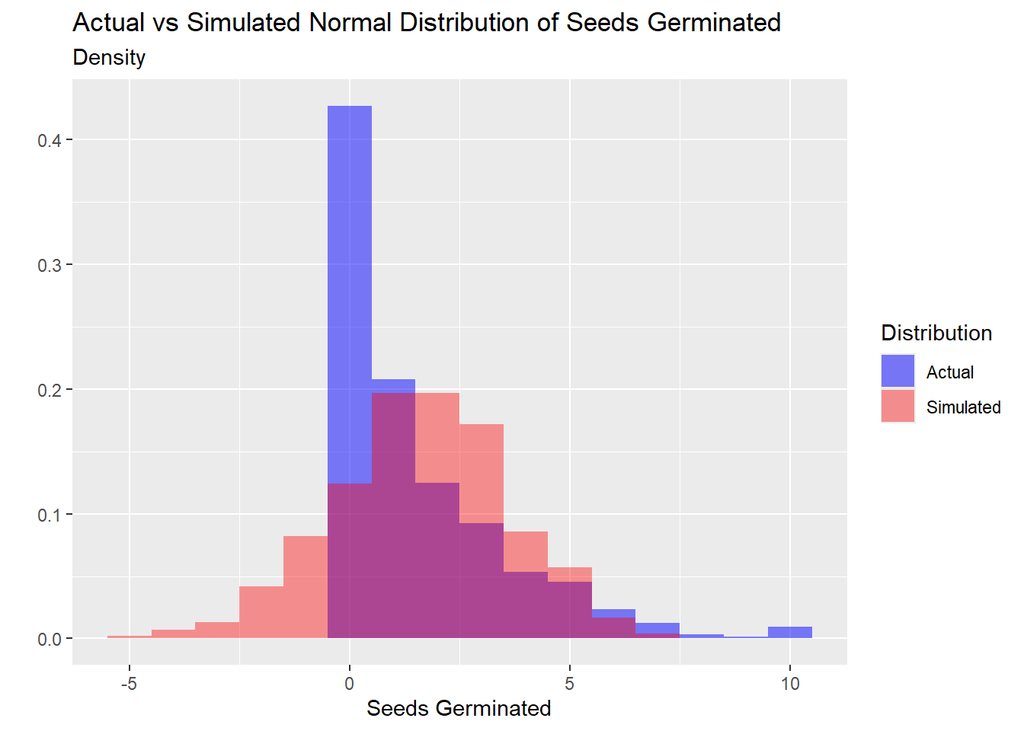

```r
set.seed(3452)
sim=data.frame(val=rnorm(c(1:1000),mean=1.534375,sd=1.972917))

germination|>
  ggplot(mapping=aes(x=seeds_germinated_out_of_10))+
  geom_histogram(aes(y=after_stat(density),
                 fill="Actual"),
                 binwidth=1,
                 alpha=0.5)+
  geom_histogram(data=sim,
                 mapping=aes(x=val,y=after_stat(density),
                 fill="Simulated"),
                 binwidth=1,
                 alpha=0.4)+
  scale_fill_manual(name="Distribution",values=c("blue","red"))+
  labs(title="Actual vs Simulated Normal Distribution of Seeds Germinated",
       x="Seeds Germinated",
       subtitle="Density",
       y="",
       fill="Distribution")
```

Comparing the normal distribution that was created using the mean and standard deviation values, there are multiple values outside of the range between specifically when noting that the amount of seeds germinated is only between 0 and 10. Because of that, the graph would be more discrete which a normal distribution can’t capture. Another reason to note is the existence of negative values and how for a normal distribution the values are more symmetric towards the mean. However, based on actual distribution, most of the values are towards 0 and is a strong right-skewed distribution.

**Question 8: For each of the week, substrate and treatment find the frequency of seeds germinated/10, and identify the highest frequency for each week and make sure to format the the table with a caption for the table.**

**Tip**

Hint: use the same frequency calculation you did for question 2.

```r
germination |>
  group_by(week,substrate,treatment_type) |>
  summarise(freq=sum(seeds_germinated_out_of_10)/40,
            .groups="drop") |>
  filter(freq==max(freq),.by=week) |>
  gt() |>
  tab_caption(
    caption = "Highest Mean Frequency of Seeds Germinated with Each Week") |>

   fmt_number(
    columns = freq,
    decimals = 1) |>

  cols_label(
    freq = "Highest Seed Frequency",
    substrate="Substrate",
    treatment_type="Treatment",
    week="Week")
```

Highest Mean Frequency of Seeds Germinated with Each Week

| Week | Substrate | Treatment | Highest Seed Frequency |
| --- | --- | --- | --- |
| 1 | Sand | Phos | 0.7 |
| 2 | Soil | Phos | 2.4 |
| 3 | Soil | Phos | 3.3 |
| 4 | Soil | Phos | 3.0 |

**Question 9: Use functions from the purrr package to calculate germination summaries separately for each species. Hint: create a summary function, summarize the dataset using `nest()`, apply a summary function to each subset using a map function, then combine the results into a single tidy table.**

```r
#Summary function:

species_summary <- function(data)
{data |>

    mutate(
      germination_percent = (seeds_germinated_out_of_10 / 10) * 100) |>

    summarize(
      mean_germination = mean(germination_percent, na.rm = TRUE),
      median_germination = median(germination_percent, na.rm = TRUE),
      sd_germination = sd(germination_percent, na.rm = TRUE),
      n = n())}

# Nest by species and apply summary function:

species_results <- germination |>

  nest(data = -species) |>

  mutate(summary = map(data, species_summary)) |>

  select(-data) |>

  unnest(summary)

species_results |>

  kable()
```

| species | mean_germination | median_germination | sd_germination | n |
| --- | --- | --- | --- | --- |
| RYE | 17.65625 | 10 | 22.03888 | 320 |
| PNG | 13.03125 | 10 | 16.83031 | 320 |

This output should give a table with one row per species showing standard deviation of germination percentage, mean and median germination, as well as number of observations.

**Question 10: Building on the code from question 9, build a table that summarizes the data by BOTH species and substrate. Hint: use `nest()` and `unnest()`.**

```r
results <- germination |>
  nest(data = c(-species, -substrate)) |>
  mutate(summary = map(data, species_summary)) |>
  select(-data) |>
  unnest(summary)

results |>
  kable()
```

| species | substrate | mean_germination | median_germination | sd_germination | n |
| --- | --- | --- | --- | --- | --- |
| RYE | Soil | 21.7500 | 10 | 26.789419 | 160 |
| RYE | Sand | 13.5625 | 10 | 14.935790 | 160 |
| PNG | Soil | 21.2500 | 20 | 19.156752 | 160 |
| PNG | Sand | 4.8125 | 0 | 8.085384 | 160 |

This output should give a table with 4 rows (each species/substrate combination) showing the standard deviation of germination percentage, mean and median germination, as well as number of observations.

Dataset collected by C. W. Sanzone in collaboration with B. Ingram-Eiser and Dr. S. Steinmaus, provided by C.W. Sanzone.